# Expresion_Dif_Poinsettia

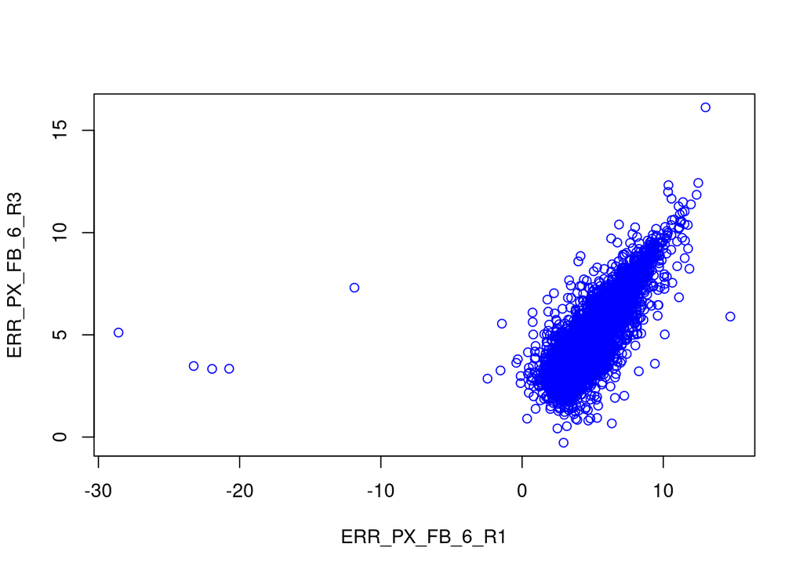

```r
# Segunda comparación
plot(log2(counts[,c("ERR_PX_FB_6_R1", "ERR_PX_FB_6_R3")]), col="blue") #COMPARACION ENTRE DOS LIBRERIAS
```

```r
lm(counts[,"ERR_PX_FB_6_R1"] ~ counts[,"ERR_PX_FB_6_R3"] ) #REGRESION LINEAL
```

```
##
## Call:
## lm(formula = counts[, "ERR_PX_FB_6_R1"] ~ counts[, "ERR_PX_FB_6_R3"])
##
## Coefficients:
##                (Intercept)  counts[, "ERR_PX_FB_6_R3"]
##                    40.5827                      0.1514
```

**Comparación de replicas con otro filtrado**

```r
#counts = counts[rowSums(cpm(counts) >= 4) >=20,]
#plot(log2(counts[,c("ERR_PX_FB_6_R2", "ERR_PX_FB_6_R3")]), col="pink")

#lm(counts[,"ERR_AZ_FB_0_R1"] ~ counts[,"ERR_AZ_FB_0_R2"] )

#Segui con misma condicion, mismo día pero diferente replica
#plot(log2(counts[, c("ERR_PX_FB_6_R2", "ERR_PX_FB_6_R3")]), col="blue")

#Por último, evalué mismo día misma replica pero diferente condicion
#plot(log2(counts[, c("ERR_AZ_FB_0_R1", "ERR_PX_FB_0_R1")]), col="grey")
```

**Comparación entre diferentes tratamientos (misma zona, diferente día)**

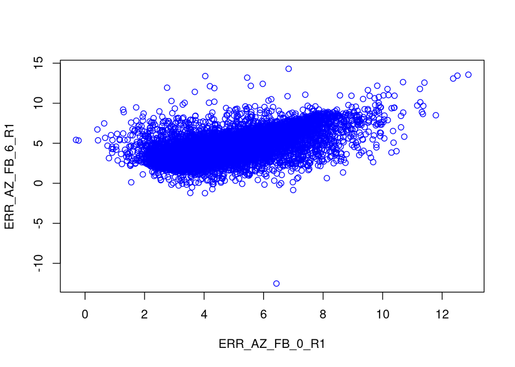

```r
plot(log2(counts[,c("ERR_AZ_FB_0_R1", "ERR_AZ_FB_6_R1")]), col="blue") #COMPARACION ENTRE DOS LIBRERIAS
```

```r
#La regresión lineal nos indica que tanto se parecen los datos
lm(counts[,"ERR_PX_FB_6_R1"] ~ counts[,"ERR_PX_FB_6_R3"] ) #REGRESION LINEAL
```

```
##
## Call:
## lm(formula = counts[, "ERR_PX_FB_6_R1"] ~ counts[, "ERR_PX_FB_6_R3"])
##
## Coefficients:
##                (Intercept)  counts[, "ERR_PX_FB_6_R3"]
##                    40.5827                      0.1514
```

**Comparación entre diferentes tratamientos (diferente zona, diferente día)**

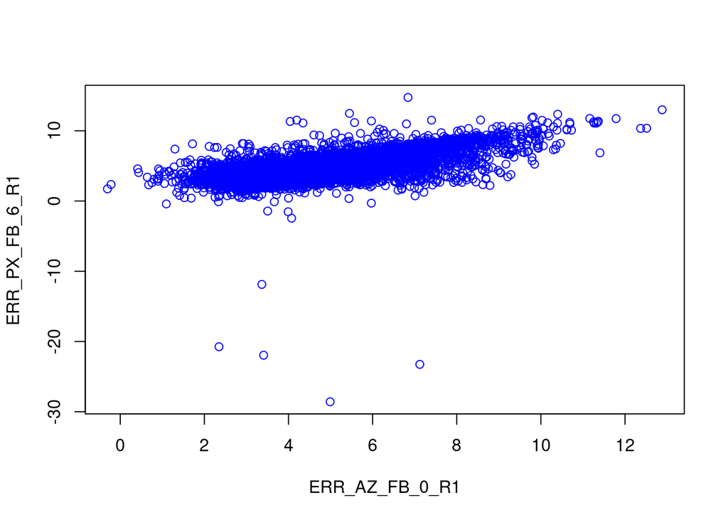

```r
plot(log2(counts[,c("ERR_AZ_FB_0_R1", "ERR_PX_FB_6_R1")]), col="blue") #COMPARACION ENTRE DOS LIBRERIAS
```

```r
#La regresión lineal nos indica que tanto se parecen los datos
lm(counts[,"ERR_AZ_FB_0_R1"] ~ counts[,"ERR_PX_FB_6_R1"] ) #REGRESION LINEAL
```

```
##
## Call:
## lm(formula = counts[, "ERR_AZ_FB_0_R1"] ~ counts[, "ERR_PX_FB_6_R1"])
##
## Coefficients:
##                (Intercept)  counts[, "ERR_PX_FB_6_R1"]
##                    31.9266                      0.2063
```

**Gráfica de regresión lineal**

```r
#Posterior a eso, me di a la tarea de realizar un filtrado de mi tabla, esto con el objetivo de reducir el ruido en mis gráficos, centrandome especificamente en el 2do experimento con una misma condicion, mismo dia pero diferente replica

min_expression <- 4
tab1_filtered = counts[rowSums(cpm(counts) >= min_expression) >= 20, ]
dim(tab1_filtered)
```

```
## [1] 17274    36
```

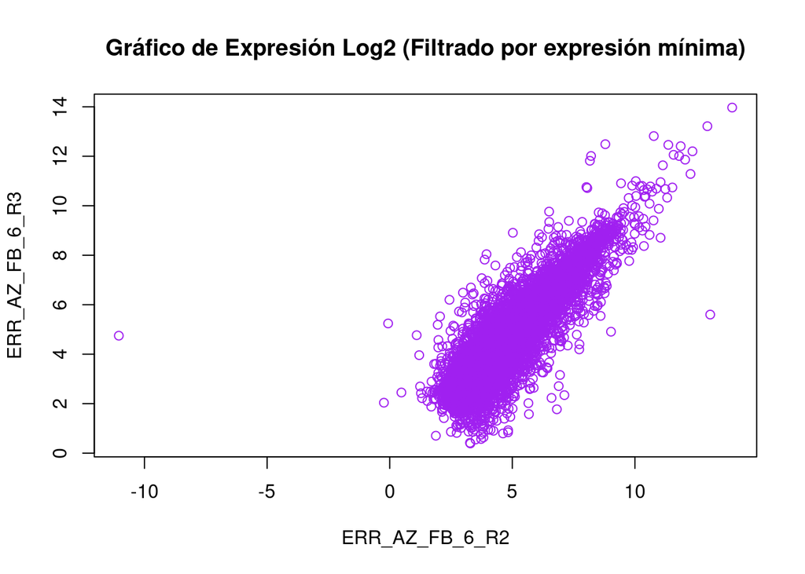

```r
plot(log2(tab1_filtered[, c("ERR_AZ_FB_6_R2", "ERR_AZ_FB_6_R3")]), col="purple",
     main="Gráfico de Expresión Log2 (Filtrado por expresión mínima)",
     xlab="ERR_AZ_FB_6_R2",
     ylab="ERR_AZ_FB_6_R3")
```

**Gráfica de regresión lineal**

```r
c_coln1 = colnames(counts)
c_coln2 = colnames(counts)

for (v in c_coln1){
  print(v)
  pdf(paste(outpath, v, ".pdf", sep=""))
  plot(log2(counts[,c(v,"ERR_AZ_FB_6_R2")]), col="blue")
  dev.off()
  #  print(lm(counts[,v] ~ counts [,"ERR_AZ_6_R2"] )) #Regresión lineal

}
```

```
## [1] "ERR_AZ_FB_0_R1"
```

```
## [1] "ERR_AZ_FB_0_R2"
```

```
## [1] "ERR_AZ_FB_0_R3"
```

```
## [1] "ERR_AZ_FB_6_R1"
```

```
## [1] "ERR_AZ_FB_6_R2"
```

```
## [1] "ERR_AZ_FB_6_R3"
```

```
## [1] "ERR_AZ_FB_2_R1"
```

```
## [1] "ERR_AZ_FB_2_R2"
```

```
## [1] "ERR_AZ_FB_2_R3"
```

```
## [1] "ERR_AZ_FB_4_R1"
```

```
## [1] "ERR_AZ_FB_4_R2"
```

```
## [1] "ERR_AZ_FB_4_R3"
```

```
## [1] "ERR_DT_FB_0_R1"
```

```
## [1] "ERR_DT_FB_0_R2"
```

```
## [1] "ERR_DT_FB_0_R3"
```

```
## [1] "ERR_DT_FB_2_R1"
```

```
## [1] "ERR_DT_FB_2_R2"
```

```
## [1] "ERR_DT_FB_2_R3"
```

```
## [1] "ERR_DT_FB_4_R1"
```

```
## [1] "ERR_DT_FB_4_R2"
```

```
## [1] "ERR_DT_FB_4_R3"
```

```
## [1] "ERR_DT_FB_6_R1"
```

```
## [1] "ERR_DT_FB_6_R2"
```

```
## [1] "ERR_DT_FB_6_R3"
```

```
## [1] "ERR_PX_FB_0_R1"
```

```
## [1] "ERR_PX_FB_0_R2"
```

```
## [1] "ERR_PX_FB_0_R3"
```

```
## [1] "ERR_PX_FB_2_R1"
```

```
## [1] "ERR_PX_FB_2_R2"
```

```
## [1] "ERR_PX_PB_2_R3"
```

```
## [1] "ERR_PX_FB_4_R1"
```

```
## [1] "ERR_PX_FB_4_R2"
```

```
## [1] "ERR_PX_FB_4_R3"
```

```
## [1] "ERR_PX_FB_6_R1"
```

```
## [1] "ERR_PX_FB_6_R2"
```

```
## [1] "ERR_PX_FB_6_R3"
```

**Agrupamiento de grupos**

```r
#Esto es para declarar los grupos que usaremos en el objeto DEList - Al igual que agrupar
grp = sub("...$", "", colnames(counts))

grp
```

```
##  [1] "ERR_AZ_FB_0" "ERR_AZ_FB_0" "ERR_AZ_FB_0" "ERR_AZ_FB_6" "ERR_AZ_FB_6"
##  [6] "ERR_AZ_FB_6" "ERR_AZ_FB_2" "ERR_AZ_FB_2" "ERR_AZ_FB_2" "ERR_AZ_FB_4"
## [11] "ERR_AZ_FB_4" "ERR_AZ_FB_4" "ERR_DT_FB_0" "ERR_DT_FB_0" "ERR_DT_FB_0"
## [16] "ERR_DT_FB_2" "ERR_DT_FB_2" "ERR_DT_FB_2" "ERR_DT_FB_4" "ERR_DT_FB_4"
## [21] "ERR_DT_FB_4" "ERR_DT_FB_6" "ERR_DT_FB_6" "ERR_DT_FB_6" "ERR_PX_FB_0"
## [26] "ERR_PX_FB_0" "ERR_PX_FB_0" "ERR_PX_FB_2" "ERR_PX_FB_2" "ERR_PX_PB_2"
## [31] "ERR_PX_FB_4" "ERR_PX_FB_4" "ERR_PX_FB_4" "ERR_PX_FB_6" "ERR_PX_FB_6"
## [36] "ERR_PX_FB_6"
```

```r
#Haciendo el objeto DEList
dge = DGEList(counts = counts, group = grp)
dge
```

```
## An object of class "DGEList"
## $counts
##                                         ERR_AZ_FB_0_R1 ERR_AZ_FB_0_R2
## NODE_3_length_11792_cov_35.025704_g1_i0        9.37373       11.40720
## NODE_4_length_11762_cov_35.124925_g1_i1       11.32000        9.44193
## NODE_5_length_11737_cov_36.098854_g2_i0       20.00720       19.90180
## NODE_7_length_11328_cov_43.312273_g3_i0       24.59450       24.69270
## NODE_8_length_10977_cov_20.560362_g4_i0       11.92900       11.05340
##                                         ERR_AZ_FB_0_R3 ERR_AZ_FB_6_R1
## NODE_3_length_11792_cov_35.025704_g1_i0        8.34797        7.55304
## NODE_4_length_11762_cov_35.124925_g1_i1       13.59490        7.17263
## NODE_5_length_11737_cov_36.098854_g2_i0       22.83710       10.36310
## NODE_7_length_11328_cov_43.312273_g3_i0       26.22480       18.13750
## NODE_8_length_10977_cov_20.560362_g4_i0       12.75070        6.33007
##                                         ERR_AZ_FB_6_R2 ERR_AZ_FB_6_R3
## NODE_3_length_11792_cov_35.025704_g1_i0        7.53972        5.89944
## NODE_4_length_11762_cov_35.124925_g1_i1        7.59526        5.14795
## NODE_5_length_11737_cov_36.098854_g2_i0       14.80900        8.47242
## NODE_7_length_11328_cov_43.312273_g3_i0       18.01680       12.70830
## NODE_8_length_10977_cov_20.560362_g4_i0        8.81931        5.17363
##                                         ERR_AZ_FB_2_R1 ERR_AZ_FB_2_R2
## NODE_3_length_11792_cov_35.025704_g1_i0        7.44371        8.22603
## NODE_4_length_11762_cov_35.124925_g1_i1        9.71547        8.50839
## NODE_5_length_11737_cov_36.098854_g2_i0        9.76652       14.35910
## NODE_7_length_11328_cov_43.312273_g3_i0       17.29100       18.24730
## NODE_8_length_10977_cov_20.560362_g4_i0        7.09509        9.94688
##                                         ERR_AZ_FB_2_R3 ERR_AZ_FB_4_R1
## NODE_3_length_11792_cov_35.025704_g1_i0        8.70700        5.22596
## NODE_4_length_11762_cov_35.124925_g1_i1        6.59871        7.59972
## NODE_5_length_11737_cov_36.098854_g2_i0       15.07860       10.99560
## NODE_7_length_11328_cov_43.312273_g3_i0       18.23410       14.05330
## NODE_8_length_10977_cov_20.560362_g4_i0       10.47190        6.67796
##                                         ERR_AZ_FB_4_R2 ERR_AZ_FB_4_R3
## NODE_3_length_11792_cov_35.025704_g1_i0        4.89866        7.08735
## NODE_4_length_11762_cov_35.124925_g1_i1        8.71095        8.32281
## NODE_5_length_11737_cov_36.098854_g2_i0        9.99849       13.92420
## NODE_7_length_11328_cov_43.312273_g3_i0       16.91830       18.50210
## NODE_8_length_10977_cov_20.560362_g4_i0        5.50770        7.75544
##                                         ERR_DT_FB_0_R1 ERR_DT_FB_0_R2
## NODE_3_length_11792_cov_35.025704_g1_i0        10.5452        11.5932
```

[output cut: 65 more lines]

```
## NODE_3_length_11792_cov_35.025704_g1_i0        6.66799        7.46856
## NODE_4_length_11762_cov_35.124925_g1_i1        7.37684        8.08404
## NODE_5_length_11737_cov_36.098854_g2_i0       12.55050       14.23760
## NODE_7_length_11328_cov_43.312273_g3_i0       14.37940       16.47240
## NODE_8_length_10977_cov_20.560362_g4_i0        7.66889        8.74899
## 17269 more rows ...
##
## $samples
##                      group lib.size norm.factors
## ERR_AZ_FB_0_R1 ERR_AZ_FB_0 720477.7            1
## ERR_AZ_FB_0_R2 ERR_AZ_FB_0 749459.5            1
## ERR_AZ_FB_0_R3 ERR_AZ_FB_0 728462.7            1
## ERR_AZ_FB_6_R1 ERR_AZ_FB_6 715453.8            1
## ERR_AZ_FB_6_R2 ERR_AZ_FB_6 774887.0            1
## 31 more rows ...
```

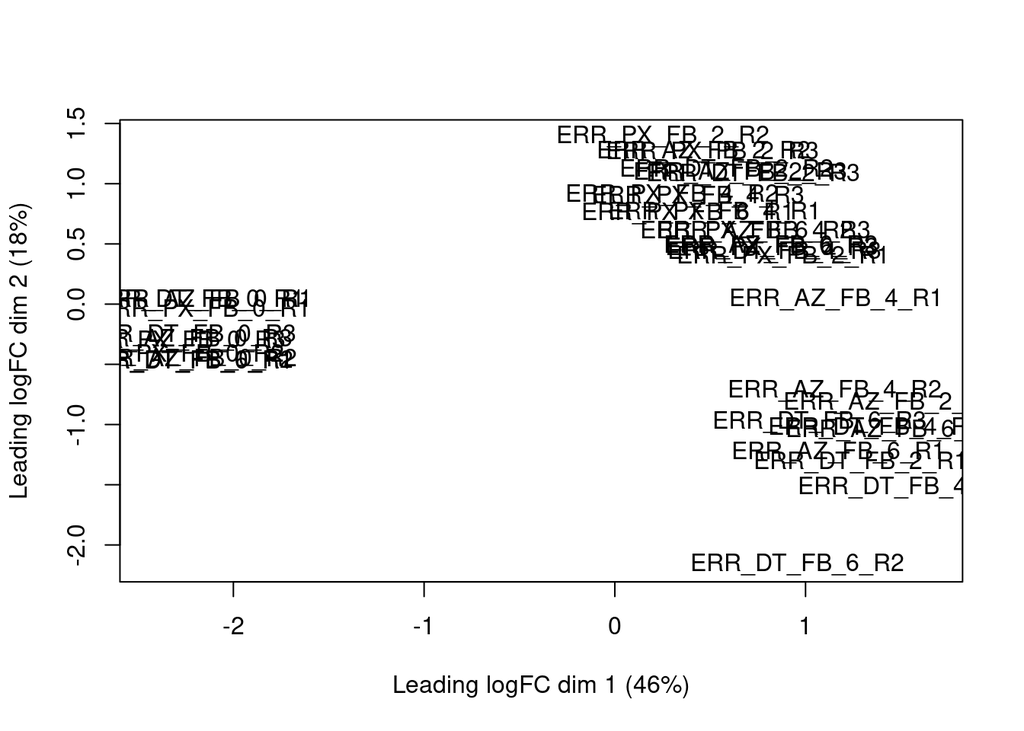

```r
#Haciendo visualización de la dispersión de nuestras librerias usando el plot MDS
#pdf(paste(outpath, "MDS.pdf", sep=""))
plotMDS(dge)
```

```r
#dev.off()
```

**Normalización**

```r
#Normalizar nuestros datos, para esto edgeR nos permite calcular un factor de normalización
dgeNorm = calcNormFactors(dge)

#Clasificacar clase
class(dgeNorm)
```

```
## [1] "DGEList"
## attr(,"package")
## [1] "edgeR"
```

```r
#Puedes visualizar los factores de normalización
dgeNorm$samples
```

[output not shown]

**Valor de dispersión**

```r
#estimaremos la dispersión entre nuestras librerías
dgeNorm = estimateCommonDisp(dgeNorm)

#podemos visualizar este valor (si no tuvieran replicas es posible ingresar este valor manualmente, pero no es ideal)

#VALOR DE DISPERSIÓN
dgeNorm$common.dispersion
```

```
## [1] 0.06760601
```

**Comparación entre diferentes tiempos** Aquí se realiza una comparación usando el valor de dispersión para obtener FC y P-value.

```r
#Calculando la expresión diferencial entre nuestras librerias (prueba pareada, exact-test)

#Pueden especificar que grupo de datos desean comparar (Misma zona, diferente tiempo)
# E.j.:ERR_AZ_FB_0 vs. ERR_AZ_FB_6
# ("A", "B") = B - A, aquí aclaramos que A es el control
diff_exp = exactTest(dgeNorm, dispersion = dgeNorm$common.dispersion, pair = c("ERR_AZ_FB_0","ERR_AZ_FB_2"))
diff_exp2 = exactTest(dgeNorm, dispersion = dgeNorm$common.dispersion, pair = c("ERR_AZ_FB_0", "ERR_AZ_FB_4"))
diff_exp3 = exactTest(dgeNorm, dispersion = dgeNorm$common.dispersion, pair = c("ERR_AZ_FB_0", "ERR_AZ_FB_6"))


#ahora visualizaremos el objeto resultante de la prueba exacta de Fisher (objeto DGEExact)
diff_exp
```

```
## An object of class "DGEExact"
## $table
##                                              logFC   logCPM    PValue
## NODE_3_length_11792_cov_35.025704_g1_i0 -0.1936660 3.724980 0.7483677
## NODE_4_length_11762_cov_35.124925_g1_i1 -0.4040347 3.841216 0.4201610
## NODE_5_length_11737_cov_36.098854_g2_i0 -0.6129175 4.486993 0.1723154
## NODE_7_length_11328_cov_43.312273_g3_i0 -0.4266603 4.806755 0.3116092
## NODE_8_length_10977_cov_20.560362_g4_i0 -0.3125588 3.872317 0.5641481
## 17269 more rows ...
##
## $comparison
## [1] "ERR_AZ_FB_0" "ERR_AZ_FB_2"
##
## $genes
## NULL
```

```r
diff_exp2
```

```
## An object of class "DGEExact"
## $table
##                                              logFC   logCPM     PValue
## NODE_3_length_11792_cov_35.025704_g1_i0 -0.7767335 3.724980 0.18678869
## NODE_4_length_11762_cov_35.124925_g1_i1 -0.4996211 3.841216 0.31295098
## NODE_5_length_11737_cov_36.098854_g2_i0 -0.8696243 4.486993 0.04726045
## NODE_7_length_11328_cov_43.312273_g3_i0 -0.6330263 4.806755 0.13248366
## NODE_8_length_10977_cov_20.560362_g4_i0 -0.8600403 3.872317 0.11448940
## 17269 more rows ...
##
## $comparison
## [1] "ERR_AZ_FB_0" "ERR_AZ_FB_4"
##
## $genes
## NULL
```

```r
diff_exp3
```

[output not shown]

**Visualización en gráfica de barras**

Hacer una gráfica de barras para comparar la expresión del gen entre los diferentes días (4-0) (misma zona)

```r
graf = counts["NODE_5_length_11737_cov_36.098854_g2_i0", c("ERR_AZ_FB_0_R1", "ERR_AZ_FB_0_R2", "ERR_AZ_FB_0_R3","ERR_AZ_FB_4_R1","ERR_AZ_FB_4_R2","ERR_AZ_FB_4_R3" )]
graf
```

```
##                                         ERR_AZ_FB_0_R1 ERR_AZ_FB_0_R2
## NODE_5_length_11737_cov_36.098854_g2_i0        20.0072        19.9018
##                                         ERR_AZ_FB_0_R3 ERR_AZ_FB_4_R1
## NODE_5_length_11737_cov_36.098854_g2_i0        22.8371        10.9956
##                                         ERR_AZ_FB_4_R2 ERR_AZ_FB_4_R3
## NODE_5_length_11737_cov_36.098854_g2_i0        9.99849        13.9242
```

```r
#graf es un data.frame
#convertir graf a un vector númerico
graf2 <- as.numeric(graf)

#Nombre de las columnas de la gráfica
colnames(graf)
```

```
## [1] "ERR_AZ_FB_0_R1" "ERR_AZ_FB_0_R2" "ERR_AZ_FB_0_R3" "ERR_AZ_FB_4_R1"
## [5] "ERR_AZ_FB_4_R2" "ERR_AZ_FB_4_R3"
```

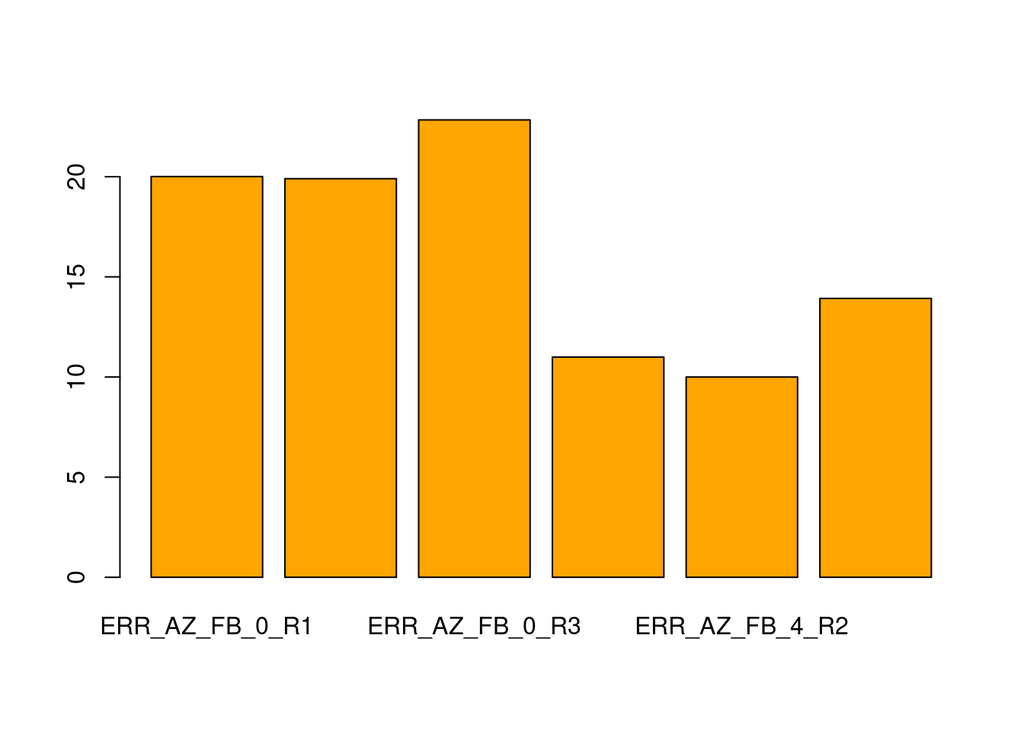

```r
#declarar nombre a la grafica 2
names(graf2)=colnames(graf)

#Hacer una gráfica de barras para comparar al expresión del gen entre los tratamientos
barplot(graf2, col = "orange")
```

Hacer una gráfica de barras para comparar la expresión del gen entre los diferentes días (6-0) (misma zona)

```r
graf3 = counts["NODE_5_length_11737_cov_36.098854_g2_i0", c("ERR_AZ_FB_0_R1", "ERR_AZ_FB_0_R2", "ERR_AZ_FB_0_R3","ERR_AZ_FB_6_R1","ERR_AZ_FB_6_R2","ERR_AZ_FB_6_R3" )]
graf3
```

```
##                                         ERR_AZ_FB_0_R1 ERR_AZ_FB_0_R2
## NODE_5_length_11737_cov_36.098854_g2_i0        20.0072        19.9018
##                                         ERR_AZ_FB_0_R3 ERR_AZ_FB_6_R1
## NODE_5_length_11737_cov_36.098854_g2_i0        22.8371        10.3631
##                                         ERR_AZ_FB_6_R2 ERR_AZ_FB_6_R3
## NODE_5_length_11737_cov_36.098854_g2_i0         14.809        8.47242
```

```r
#graf es un data.frame
#convertir graf a un vector númerico
graf4 <- as.numeric(graf3)

#Nombre de las columnas de la gráfica
colnames(graf3)
```

```
## [1] "ERR_AZ_FB_0_R1" "ERR_AZ_FB_0_R2" "ERR_AZ_FB_0_R3" "ERR_AZ_FB_6_R1"
## [5] "ERR_AZ_FB_6_R2" "ERR_AZ_FB_6_R3"
```

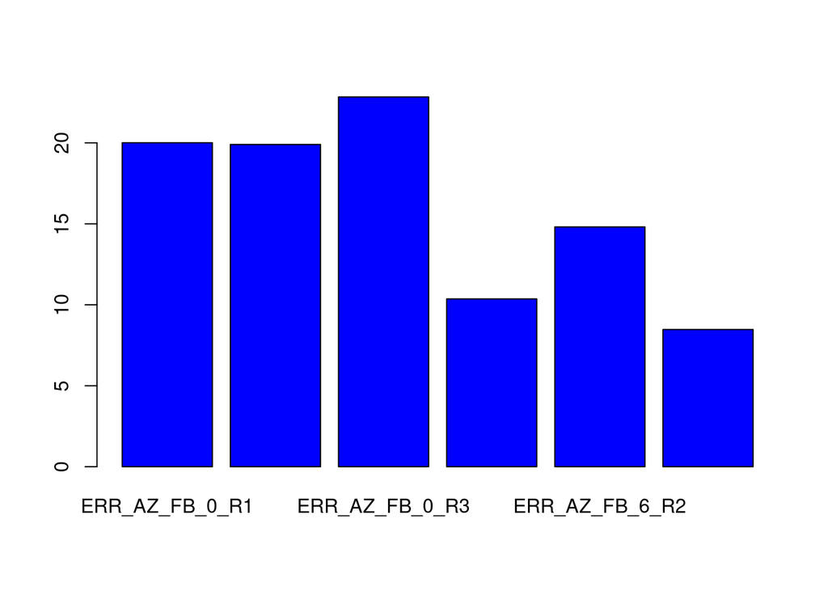

```r
#declarar nombre a la grafica 2
names(graf4)=colnames(graf3)

#Hacer una gráfica de barras para comparar al expresión del gen entre los tratamientos
barplot(graf4, col = "blue")
```

**Comparación entre diferentes zonas**

```r
#Calculando la expresión diferencial entre nuestras librerias (prueba pareada, exact-test)

#Pueden especificar que grupo de datos desean comparar (diferente zona, mismo tiempo)
# E.j.:ERR_AZ_FB_0 vs. ERR_AZ_FB_6
#PX = Proximal
#AZ = Abscission
#DT = Distal

diff_exp4 = exactTest(dgeNorm, dispersion = dgeNorm$common.dispersion, pair = c("ERR_AZ_FB_0","ERR_PX_FB_0"))
diff_exp5 = exactTest(dgeNorm, dispersion = dgeNorm$common.dispersion, pair = c("ERR_AZ_FB_0", "ERR_DT_FB_0" ))


#ahora visualizaremos el objeto resultante de la prueba exacta de Fisher (objeto DGEExact)
diff_exp4
```

```
## An object of class "DGEExact"
## $table
##                                               logFC   logCPM    PValue
## NODE_3_length_11792_cov_35.025704_g1_i0  0.12147629 3.724980 0.8442655
## NODE_4_length_11762_cov_35.124925_g1_i1 -0.03958651 3.841216 1.0000000
## NODE_5_length_11737_cov_36.098854_g2_i0  0.10958950 4.486993 0.8247448
## NODE_7_length_11328_cov_43.312273_g3_i0  0.05219188 4.806755 0.9230091
## NODE_8_length_10977_cov_20.560362_g4_i0  0.06029426 3.872317 1.0000000
## 17269 more rows ...
##
## $comparison
## [1] "ERR_AZ_FB_0" "ERR_PX_FB_0"
##
## $genes
## NULL
```

```r
diff_exp5
```

```
## An object of class "DGEExact"
## $table
##                                                logFC   logCPM    PValue
## NODE_3_length_11792_cov_35.025704_g1_i0 -0.006557586 3.724980 1.0000000
## NODE_4_length_11762_cov_35.124925_g1_i1 -0.160402441 3.841216 0.7804529
## NODE_5_length_11737_cov_36.098854_g2_i0 -0.111393425 4.486993 0.8159097
## NODE_7_length_11328_cov_43.312273_g3_i0 -0.128673199 4.806755 0.7620448
## NODE_8_length_10977_cov_20.560362_g4_i0 -0.098628216 3.872317 0.9290377
## 17269 more rows ...
##
## $comparison
## [1] "ERR_AZ_FB_0" "ERR_DT_FB_0"
##
## $genes
## NULL
```

**Correción del P-value con False Discovery Rate**

Se uso la función topTags()

```r
#diff_exp
topTags(diff_exp)
```

```
## Comparison of groups:  ERR_AZ_FB_2-ERR_AZ_FB_0
##                                                  logFC   logCPM       PValue
## NODE_66077_length_225_cov_4.686813_g50867_i0  8.917142 11.30127 9.973198e-84
## NODE_38262_length_689_cov_4.258514_g24065_i0  8.799268 10.99909 3.223631e-81
## NODE_43205_length_549_cov_11.590909_g28187_i0 8.169580 11.63585 7.046139e-79
## NODE_49363_length_406_cov_22.055096_g34160_i0 7.695013 12.27260 6.194448e-75
## NODE_43320_length_546_cov_49.280318_g28296_i0 7.609382 12.83809 4.370972e-74
## NODE_62988_length_245_cov_3.297030_g47778_i0  8.326056 10.39558 2.647456e-72
## NODE_41062_length_608_cov_25.053097_g26312_i0 7.570380 11.49676 4.684557e-70
## NODE_36954_length_727_cov_68.980994_g23083_i0 6.947133 11.92618 3.416739e-65
## NODE_98550_length_124_cov_14.049383_g83340_i0 6.776087 11.62714 1.175766e-63
## NODE_39204_length_660_cov_57.051864_g24799_i0 6.724559 11.44300 1.157952e-61
##                                                        FDR
## NODE_66077_length_225_cov_4.686813_g50867_i0  1.722770e-79
## NODE_38262_length_689_cov_4.258514_g24065_i0  2.784250e-77
## NODE_43205_length_549_cov_11.590909_g28187_i0 4.057167e-75
## NODE_49363_length_406_cov_22.055096_g34160_i0 2.675073e-71
## NODE_43320_length_546_cov_49.280318_g28296_i0 1.510083e-70
## NODE_62988_length_245_cov_3.297030_g47778_i0  7.622026e-69
## NODE_41062_length_608_cov_25.053097_g26312_i0 1.156015e-66
## NODE_36954_length_727_cov_68.980994_g23083_i0 7.377595e-62
## NODE_98550_length_124_cov_14.049383_g83340_i0 2.256687e-60
## NODE_39204_length_660_cov_57.051864_g24799_i0 2.000246e-58
```

```r
dim(topTags(diff_exp))
```

```
## [1] 10  4
```

```r
deTab1 = topTags(diff_exp, n=Inf)$table #Guardar la tabla con todos los valores en un objeto de R y poder usarlo posteriormente es importante para nuestros fines.

#diff_exp2
topTags(diff_exp2)
```

```
## Comparison of groups:  ERR_AZ_FB_4-ERR_AZ_FB_0
##                                                  logFC   logCPM       PValue
## NODE_31950_length_891_cov_15.926887_g4516_i1  8.484796 11.17986 2.138465e-80
## NODE_43320_length_546_cov_49.280318_g28296_i0 7.687884 12.83809 3.213840e-75
## NODE_62988_length_245_cov_3.297030_g47778_i0  8.126210 10.39558 9.967200e-70
## NODE_41062_length_608_cov_25.053097_g26312_i0 7.506795 11.49676 2.886769e-69
## NODE_39673_length_647_cov_4.359272_g25181_i0  7.881603  9.00562 3.589938e-65
## NODE_40465_length_625_cov_10.733677_g25825_i0 7.019767 10.94625 9.903507e-64
## NODE_36954_length_727_cov_68.980994_g23083_i0 6.818700 11.92618 1.432386e-63
## NODE_44480_length_517_cov_6.251055_g29365_i0  7.197964 10.33205 1.280005e-62
## NODE_31149_length_919_cov_13.807078_g19030_i0 6.826114 11.03962 3.620948e-60
## NODE_39204_length_660_cov_57.051864_g24799_i0 6.407023 11.44300 1.212437e-57
##                                                        FDR
## NODE_31950_length_891_cov_15.926887_g4516_i1  3.693984e-76
## NODE_43320_length_546_cov_49.280318_g28296_i0 2.775794e-71
## NODE_62988_length_245_cov_3.297030_g47778_i0  5.739114e-66
## NODE_41062_length_608_cov_25.053097_g26312_i0 1.246651e-65
## NODE_39673_length_647_cov_4.359272_g25181_i0  1.240252e-61
## NODE_40465_length_625_cov_10.733677_g25825_i0 2.851220e-60
## NODE_36954_length_727_cov_68.980994_g23083_i0 3.534720e-60
## NODE_44480_length_517_cov_6.251055_g29365_i0  2.763850e-59
## NODE_31149_length_919_cov_13.807078_g19030_i0 6.949806e-57
## NODE_39204_length_660_cov_57.051864_g24799_i0 2.094364e-54
```

```r
dim(topTags(diff_exp2))
```

```
## [1] 10  4
```

```r
deTab2 = topTags(diff_exp2, n=Inf)$table

#diff_exp3
topTags(diff_exp3)
```

```
## Comparison of groups:  ERR_AZ_FB_6-ERR_AZ_FB_0
##                                                  logFC    logCPM       PValue
## NODE_31950_length_891_cov_15.926887_g4516_i1  9.041544 11.179862 1.152216e-87
## NODE_62988_length_245_cov_3.297030_g47778_i0  9.118937 10.395582 3.217675e-83
## NODE_43320_length_546_cov_49.280318_g28296_i0 7.593296 12.838091 5.542808e-74
## NODE_41062_length_608_cov_25.053097_g26312_i0 7.850292 11.496755 1.116750e-73
## NODE_44480_length_517_cov_6.251055_g29365_i0  7.754429 10.332054 8.689956e-70
## NODE_31149_length_919_cov_13.807078_g19030_i0 7.275040 11.039624 6.432625e-66
## NODE_36954_length_727_cov_68.980994_g23083_i0 6.859637 11.926177 3.977211e-64
## NODE_39204_length_660_cov_57.051864_g24799_i0 6.873439 11.442999 1.309868e-63
## NODE_39673_length_647_cov_4.359272_g25181_i0  7.737778  9.005620 3.355816e-63
## NODE_67879_length_216_cov_1.179191_g52669_i0  7.271462  8.833033 4.018609e-59
##                                                        FDR
## NODE_31950_length_891_cov_15.926887_g4516_i1  1.990339e-83
## NODE_62988_length_245_cov_3.297030_g47778_i0  2.779106e-79
## NODE_43320_length_546_cov_49.280318_g28296_i0 3.191549e-70
## NODE_41062_length_608_cov_25.053097_g26312_i0 4.822686e-70
## NODE_44480_length_517_cov_6.251055_g29365_i0  3.002206e-66
## NODE_31149_length_919_cov_13.807078_g19030_i0 1.851953e-62
## NODE_36954_length_727_cov_68.980994_g23083_i0 9.814620e-61
## NODE_39204_length_660_cov_57.051864_g24799_i0 2.828332e-60
## NODE_39673_length_647_cov_4.359272_g25181_i0  6.440929e-60
## NODE_67879_length_216_cov_1.179191_g52669_i0  6.941746e-56
```

```r
dim(topTags(diff_exp3))
```

```
## [1] 10  4
```

```r
deTab3 = topTags(diff_exp3, n=Inf)$table
```

```r
#diff_exp4
topTags(diff_exp4)
```

```
## Comparison of groups:  ERR_PX_FB_0-ERR_AZ_FB_0
##                                                      logFC   logCPM
## NODE_4107_length_2772_cov_25828.409307_g58_i29    2.269744 8.758164
## NODE_90736_length_151_cov_1.194444_g75526_i0     -2.259744 5.229920
## NODE_59562_length_271_cov_25625.570175_g44352_i0 -1.826872 6.084781
## NODE_78953_length_175_cov_0.939394_g63743_i0     -2.076227 5.309891
## NODE_6512_length_2375_cov_24782.429674_g58_i35   -1.611098 6.230598
## NODE_31271_length_914_cov_24542.401837_g19102_i0 -1.730444 4.835247
## NODE_26082_length_1110_cov_25071.191190_g58_i42  -1.400586 5.739729
## NODE_96722_length_145_cov_1.029412_g81512_i0     -1.210811 9.331056
## NODE_1964_length_3437_cov_25570.346494_g58_i23   -1.372887 5.285672
## NODE_26726_length_1086_cov_20.069032_g16295_i0    1.525101 5.392254
##                                                        PValue          FDR
## NODE_4107_length_2772_cov_25828.409307_g58_i29   1.126130e-11 1.945277e-07
## NODE_90736_length_151_cov_1.194444_g75526_i0     4.018917e-08 3.471139e-04
## NODE_59562_length_271_cov_25625.570175_g44352_i0 7.279824e-08 4.191723e-04
## NODE_78953_length_175_cov_0.939394_g63743_i0     2.836462e-07 1.224926e-03
## NODE_6512_length_2375_cov_24782.429674_g58_i35   1.570513e-06 5.425808e-03
## NODE_31271_length_914_cov_24542.401837_g19102_i0 1.546099e-05 4.451220e-02
## NODE_26082_length_1110_cov_25071.191190_g58_i42  6.967784e-05 1.719450e-01
## NODE_96722_length_145_cov_1.029412_g81512_i0     1.546961e-04 3.166541e-01
## NODE_1964_length_3437_cov_25570.346494_g58_i23   1.649813e-04 3.166541e-01
## NODE_26726_length_1086_cov_20.069032_g16295_i0   2.036150e-04 3.517245e-01
```

```r
dim(topTags(diff_exp4))
```

```
## [1] 10  4
```

```r
deTab4 = topTags(diff_exp4, n=Inf)$table

#diff_exp5
topTags(diff_exp5)
```

```
## Comparison of groups:  ERR_DT_FB_0-ERR_AZ_FB_0
##                                                      logFC   logCPM
## NODE_59562_length_271_cov_25625.570175_g44352_i0 -2.258019 6.084781
## NODE_6512_length_2375_cov_24782.429674_g58_i35   -2.222732 6.230598
## NODE_42476_length_568_cov_2998.443810_g27531_i0  -2.282689 6.419605
## NODE_4107_length_2772_cov_25828.409307_g58_i29    1.745977 8.758164
## NODE_78953_length_175_cov_0.939394_g63743_i0     -2.127467 5.309891
## NODE_90736_length_151_cov_1.194444_g75526_i0     -2.073969 5.229920
## NODE_1957_length_3437_cov_25875.296995_g58_i16   -1.612028 6.219410
## NODE_1953_length_3437_cov_25907.473188_g58_i12   -1.668652 5.229373
## NODE_1961_length_3437_cov_25688.987036_g58_i20   -1.826994 4.699569
## NODE_89727_length_152_cov_4.522936_g74517_i0     -1.431914 8.550767
##                                                        PValue          FDR
## NODE_59562_length_271_cov_25625.570175_g44352_i0 7.751857e-11 1.144833e-06
## NODE_6512_length_2375_cov_24782.429674_g58_i35   1.325499e-10 1.144833e-06
## NODE_42476_length_568_cov_2998.443810_g27531_i0  2.802210e-08 1.613513e-04
## NODE_4107_length_2772_cov_25828.409307_g58_i29   1.334878e-07 5.634713e-04
## NODE_78953_length_175_cov_0.939394_g63743_i0     1.630981e-07 5.634713e-04
## NODE_90736_length_151_cov_1.194444_g75526_i0     3.560997e-07 1.025211e-03
## NODE_1957_length_3437_cov_25875.296995_g58_i16   4.476503e-06 1.104673e-02
## NODE_1953_length_3437_cov_25907.473188_g58_i12   7.302130e-06 1.519216e-02
## NODE_1961_length_3437_cov_25688.987036_g58_i20   7.915332e-06 1.519216e-02
## NODE_89727_length_152_cov_4.522936_g74517_i0     1.389368e-05 2.247267e-02
```

```r
dim(topTags(diff_exp5))
```

```
## [1] 10  4
```

```r
deTab5 = topTags(diff_exp5, n=Inf)$table
```

**Función de for para filtrar con un logFC mayor a 1**

```
## [1] "deTab1"
## [1] "total de diferenciales:  2070"
## [1] "número de genes inducidos:  1166"
## [1] "número de genes reprimidos:  1393"
## [1] " "
```

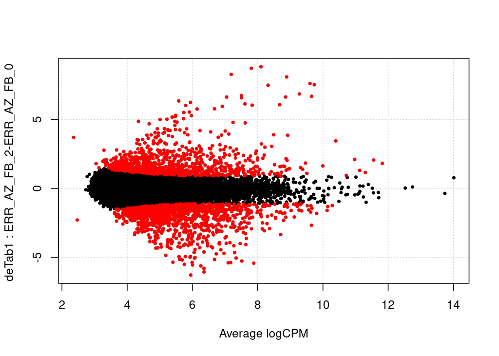

```
## [1] "deTab2"
## [1] "total de diferenciales:  2347"
## [1] "número de genes inducidos:  1266"
## [1] "número de genes reprimidos:  1567"
## [1] " "
```

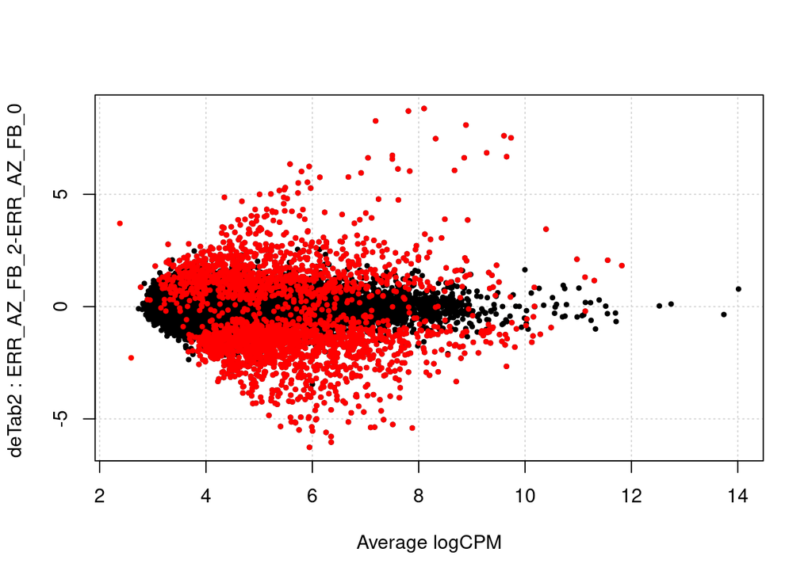

```
## [1] "deTab3"
## [1] "total de diferenciales:  2714"
## [1] "número de genes inducidos:  1325"
## [1] "número de genes reprimidos:  1861"
## [1] " "
```

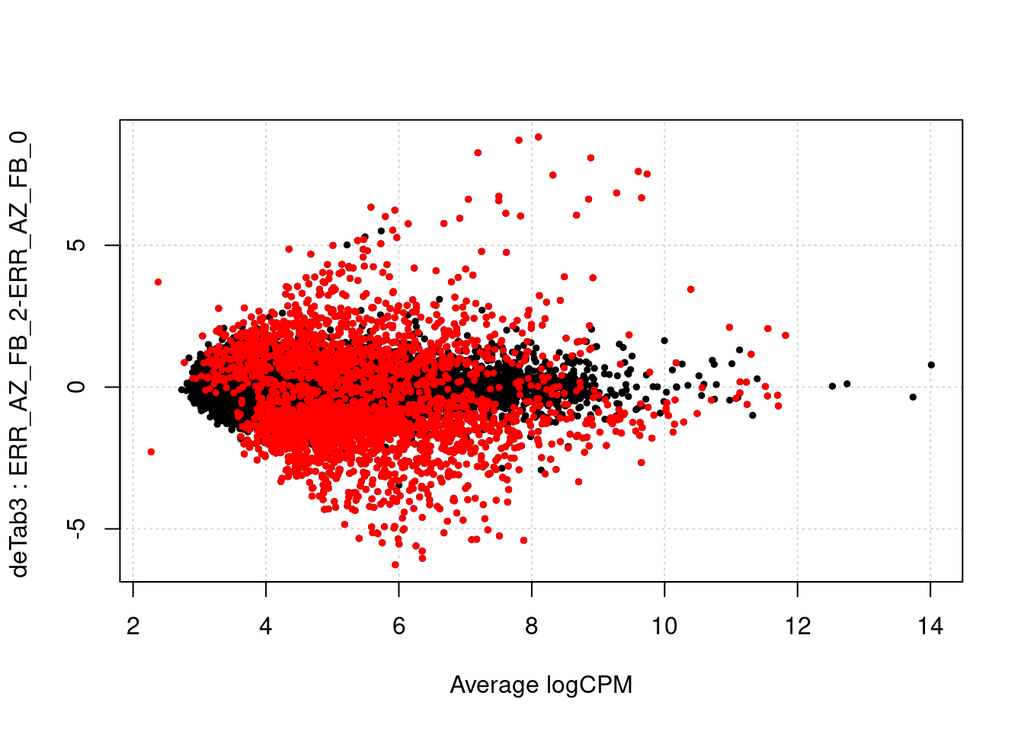

```r
#Aquí esta filtrados los genes con un cambio significativo, pero también podemos filtrar por cualquier criterio matematico.

#Hacer una lista
comparacion = c("deTab1","deTab2","deTab3")

#Hacer un ciclo para obtener la filtración
for (i in comparacion) {
  df <- get(i)
  print(i)

  deGenes = rownames(df)[df$FDR < 0.05 & abs(df$logFC) > 1]
  down = row.names(df)[df$logFC < -1]
  over = row.names(df) [df$logFC > 1]

  #para saber el número total de genes que pasan estos filtros (genes diferenciales según nuestro criterio matemático)

  print(paste("total de diferenciales: ", length(deGenes)))
  print(paste("número de genes inducidos: ", length(over)))
  print(paste("número de genes reprimidos: ", length(down)))
  print(" ")

  plotSmear(dge, de.tags = deGenes, ylab = i, cex = 0.5)
}
```

```r
#df_1 <- c("deTab1","deTab2", "deTab3")
#x <- row.names(df)[!is.na(df) & df > 5]
#y <- row.names(df)[!is.na(df$log) & df$log > -5]
#z <- row.names(df)[!is.na(df$log) & df$log > -2]

# Omitir filas que tengan NA
#x <- x[!is.na(x)]
#y <- y[!is.na(y)]
#z <- z[!is.na(z)]

#install.packages("VennDiagram")
#library(grid)
#library(VennDiagram)
```

```r
#if (length(x) > 0 & length(y) > 0 & length(z) > 0) {
  #venn.plot <- venn.diagram(
    #x = list(
      #Set1 = x,
      #Set2 = y,
      #Set3 = z
    #),
    #category.names = c("Group 1", "Group 2", "Group 3"),
    #filename = NULL,
    #output = TRUE
  #)

  # Mostrar el diagrama
  #grid.draw(venn.plot)
#} else {
  #print("Error: Uno o más conjuntos están vacíos o contienen NA.")
#}
```

```r
#venn.plot <- venn.diagram(
  #x = list(
    #Set1 = x,
    #Set2 = y,
    #Set3 = z
  #),
  #category.names = c("Group 1", "Group 2", "Group 3"),
  #filename = NULL, #Esto es para que el diagrama se devuelva como objeto en lugar de guardarse en un archivo
  #output =TRUE
#)

#Mostrar el diagrama
#grid.draw(venn.plot)
```

**Gráficos de expresión diferencial**

```r
#Instalando las paqueterias
#install.packages("gplots")
#install.packages("RColorBrewer")

library("gplots")
library("RColorBrewer")
```

**Normalizamos nuestros datos de expresión por cpm**

```r
#normalizamos nuestros datos de expresión por cuentas por millón
normalizados = cpm(counts)

#extraemos la expresión de los genes diferenciales
normalizados_diferenciales = normalizados[deGenes,]

#veamos cómo se ve esta tablita
head(normalizados_diferenciales)
```

```
##                                               ERR_AZ_FB_0_R1 ERR_AZ_FB_0_R2
## NODE_31950_length_891_cov_15.926887_g4516_i1       22.819305       15.35547
## NODE_62988_length_245_cov_3.297030_g47778_i0        9.380929       10.71486
## NODE_43320_length_546_cov_49.280318_g28296_i0      60.642823       67.42873
## NODE_41062_length_608_cov_25.053097_g26312_i0      25.442565       25.65836
## NODE_44480_length_517_cov_6.251055_g29365_i0       17.889243       14.73475
## NODE_31149_length_919_cov_13.807078_g19030_i0      28.200596       23.23982
##                                               ERR_AZ_FB_0_R3 ERR_AZ_FB_6_R1
## NODE_31950_length_891_cov_15.926887_g4516_i1       14.665267      14992.723
## NODE_62988_length_245_cov_3.297030_g47778_i0        4.844696       5476.678
## NODE_43320_length_546_cov_49.280318_g28296_i0      61.026460      13084.955
## NODE_41062_length_608_cov_25.053097_g26312_i0      20.589523       6244.792
## NODE_44480_length_517_cov_6.251055_g29365_i0       13.404475       3816.822
## NODE_31149_length_919_cov_13.807078_g19030_i0      18.576792       5285.373
##                                               ERR_AZ_FB_6_R2 ERR_AZ_FB_6_R3
## NODE_31950_length_891_cov_15.926887_g4516_i1       2251.6188       9508.659
## NODE_62988_length_245_cov_3.297030_g47778_i0        572.3816       7569.039
## NODE_43320_length_546_cov_49.280318_g28296_i0     10240.9261      12534.983
## NODE_41062_length_608_cov_25.053097_g26312_i0      4609.6789       5437.961
## NODE_44480_length_517_cov_6.251055_g29365_i0        382.2945       5442.165
## NODE_31149_length_919_cov_13.807078_g19030_i0       369.6539       4755.839
##                                               ERR_AZ_FB_2_R1 ERR_AZ_FB_2_R2
## NODE_31950_length_891_cov_15.926887_g4516_i1        5038.627      170.69539
## NODE_62988_length_245_cov_3.297030_g47778_i0        7622.912       41.95231
## NODE_43320_length_546_cov_49.280318_g28296_i0      11692.114     7857.59255
## NODE_41062_length_608_cov_25.053097_g26312_i0       3577.060     2534.10931
## NODE_44480_length_517_cov_6.251055_g29365_i0        2258.633      149.01280
## NODE_31149_length_919_cov_13.807078_g19030_i0       3337.568       60.48202
##                                               ERR_AZ_FB_2_R3 ERR_AZ_FB_4_R1
## NODE_31950_length_891_cov_15.926887_g4516_i1       410.34850      5561.3850
## NODE_62988_length_245_cov_3.297030_g47778_i0        22.93296       770.8029
## NODE_43320_length_546_cov_49.280318_g28296_i0    15062.55773     12981.1296
## NODE_41062_length_608_cov_25.053097_g26312_i0     6684.48323      4588.1724
## NODE_44480_length_517_cov_6.251055_g29365_i0       446.32540      2073.9028
## NODE_31149_length_919_cov_13.807078_g19030_i0     1507.71912      2508.2639
##                                               ERR_AZ_FB_4_R2 ERR_AZ_FB_4_R3
## NODE_31950_length_891_cov_15.926887_g4516_i1       12166.003      289.11873
## NODE_62988_length_245_cov_3.297030_g47778_i0        5720.395      168.02310
## NODE_43320_length_546_cov_49.280318_g28296_i0      17240.456     7236.78696
## NODE_41062_length_608_cov_25.053097_g26312_i0       5214.625     2811.59446
```

[output cut: 71 more lines]

```
## NODE_31149_length_919_cov_13.807078_g19030_i0       92.87578       40.54968
##                                               ERR_PX_FB_4_R3 ERR_PX_FB_6_R1
## NODE_31950_length_891_cov_15.926887_g4516_i1       150.53932      3144.6998
## NODE_62988_length_245_cov_3.297030_g47778_i0        58.97354       111.5680
## NODE_43320_length_546_cov_49.280318_g28296_i0     4443.08968      6952.4866
## NODE_41062_length_608_cov_25.053097_g26312_i0     1919.74813      3571.9173
## NODE_44480_length_517_cov_6.251055_g29365_i0        97.58939       240.0824
## NODE_31149_length_919_cov_13.807078_g19030_i0       30.35557       345.8598
##                                               ERR_PX_FB_6_R2 ERR_PX_FB_6_R3
## NODE_31950_length_891_cov_15.926887_g4516_i1       1291.3952     1103.29859
## NODE_62988_length_245_cov_3.297030_g47778_i0        614.2793      110.73320
## NODE_43320_length_546_cov_49.280318_g28296_i0      4605.3830     7081.94735
## NODE_41062_length_608_cov_25.053097_g26312_i0      1883.0347     2691.90018
## NODE_44480_length_517_cov_6.251055_g29365_i0        306.8932      219.00220
## NODE_31149_length_919_cov_13.807078_g19030_i0       572.7672       41.63108
```

**HeatMap**

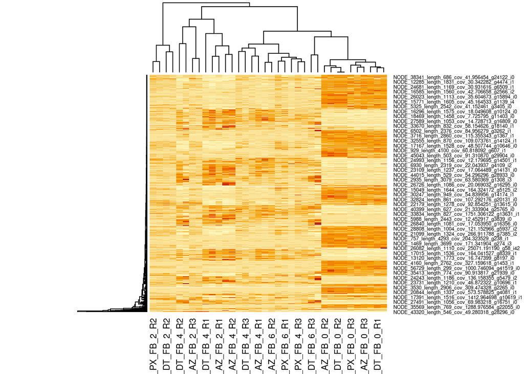

```r
#hagamos un HEATMAP!
heatmap(normalizados_diferenciales)
```

**Comparación de no-normalizados**

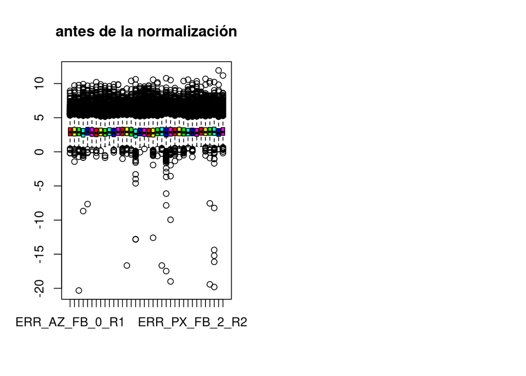

```r
par(mfrow=c(1,2))

boxplot(log(counts),col=rainbow(6), main="antes de la normalización")
```

**Comparación con después de la normalización**

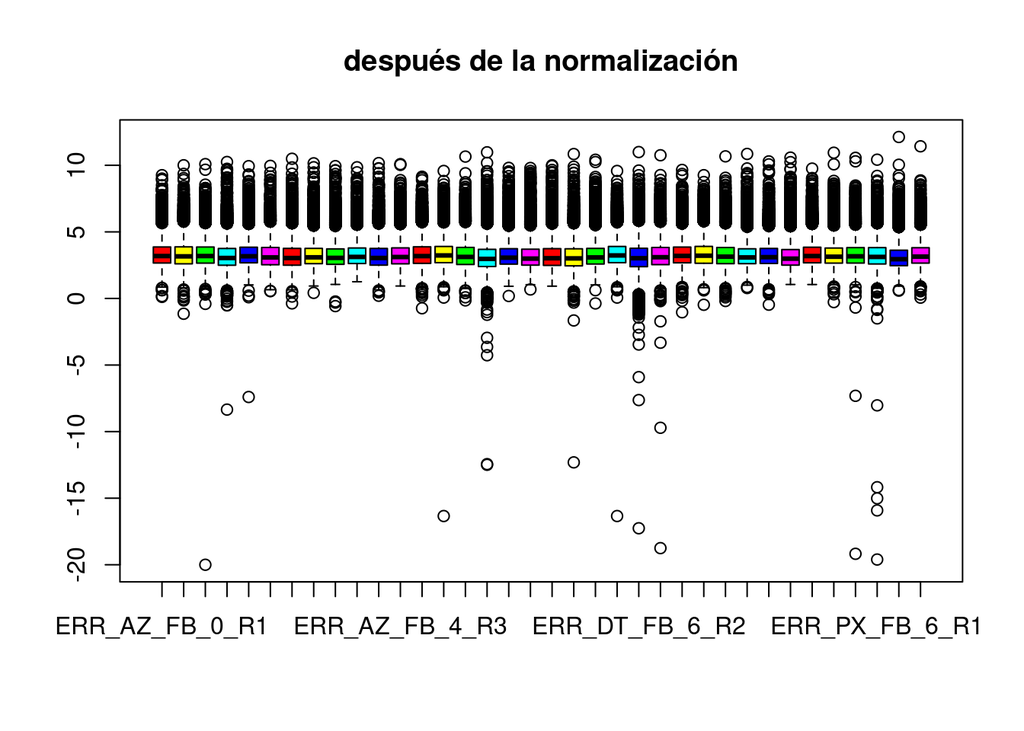

```r
boxplot(log(normalizados), col=rainbow(6), main="después de la normalización")
```

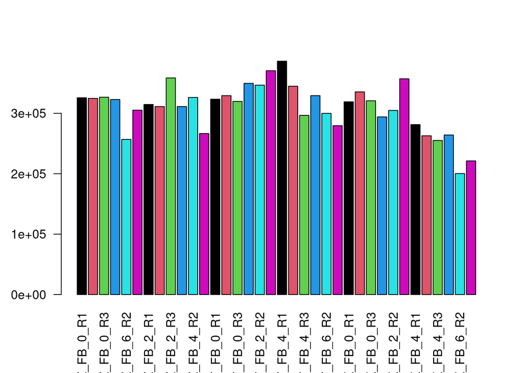

```r
barplot(apply(normalizados_diferenciales,2,sum),las=2, cex.names = 1, col = (1:6))
```